# Exploratory Data Analysis Report

Al Omrane

2021-06-30

# 1 Introduction

The EDA Report provides exploratory data analysis information on objects that inherit data.frame and data.frame.

## 1.1 Information of Dataset

The dataset that generated the EDA Report is an **‘data.frame’** object. It consists of **6,690 observations** and **22 variables**.

## 1.2 Information of Variables

The variable information of the data set that generated the EDA Report is shown in the following table.:

Information of Variables

| variables | types | missing_count | missing_percent | unique_count | unique_rate |
| --- | --- | --- | --- | --- | --- |
| Opération | character | 0 | 0.00 | 116 | 0.017 |
| Division | integer | 0 | 0.00 | 5 | 0.001 |
| Description | character | 0 | 0.00 | 5 | 0.001 |
| Designation | character | 0 | 0.00 | 116 | 0.017 |
| TypeUnité | character | 0 | 0.00 | 7 | 0.001 |
| TypeProduit | character | 0 | 0.00 | 33 | 0.005 |
| NombreUnité | numeric | 0 | 0.00 | 1 | 0.000 |
| StatutADV | numeric | 0 | 0.00 | 3 | 0.000 |
| Superficie | numeric | 0 | 0.00 | 452 | 0.068 |
| PrixUnitaire | numeric | 0 | 0.00 | 701 | 0.105 |
| PrixTotal | numeric | 0 | 0.00 | 1722 | 0.257 |
| NuméroClient | character | 0 | 0.00 | 5844 | 0.874 |
| Client | character | 0 | 0.00 | 2894 | 0.433 |
| Dossier | character | 0 | 0.00 | 6690 | 1.000 |
| TypeDocument | character | 0 | 0.00 | 4 | 0.001 |
| DésignationTypeDeDocument | character | 0 | 0.00 | 4 | 0.001 |
| Création | Date | 6 | 0.09 | 1559 | 0.233 |
| Vers1 | numeric | 0 | 0.00 | 1330 | 0.199 |
| Vers2 | numeric | 0 | 0.00 | 1038 | 0.155 |
| Vers3 | numeric | 0 | 0.00 | 764 | 0.114 |
| TotalVersement | numeric | 0 | 0.00 | 2047 | 0.306 |
| ResteàPayer | numeric | 0 | 0.00 | 2727 | 0.408 |

The target variable of the data is **‘Description’**, and the data type of the variable is **character**.

## 1.3 About EDA Report

EDA reports provide information and visualization results that support the EDA process. In particular, it provides a variety of information to understand the relationship between the target variable and the rest of the variables of interest.

# 2 Univariate Analysis

## 2.1 Descriptive Statistics

edaData  
22 Variables 6690 Observations

Opération

| n | missing | distinct |
| --- | --- | --- |
| 6690 | 0 | 116 |

| lowest : | 180011.01 | 180017.01 | 180018.01 | 180023.01 | 180025.01 |
| --- | --- | --- | --- | --- | --- |
| highest: | 180620.01 | 180621.01 | 180621.02 | 180621.03 | 180630.02 |

Division

| n | missing | distinct | Info | Mean | Gmd |
| --- | --- | --- | --- | --- | --- |
| 6690 | 0 | 5 | 0.927 | 1803 | 1.378 |

lowest : 1801 1802 1803 1804 1805 , highest: 1801 1802 1803 1804 1805

```
 Value       1801  1802  1803  1804  1805
 Frequency    265  1361  2039   857  2168
 Proportion 0.040 0.203 0.305 0.128 0.324
```

Description

| n | missing | distinct |
| --- | --- | --- |
| 6690 | 0 | 5 |

| lowest : | Agence Oujda | Berkane | Jerada-Figuig | Nador - Driouch | Taourirt |
| --- | --- | --- | --- | --- | --- |
| highest: | Agence Oujda | Berkane | Jerada-Figuig | Nador - Driouch | Taourirt |

```
 Value         Agence Oujda         Berkane   Jerada-Figuig Nador - Driouch
 Frequency              265            1361             857            2039
 Proportion           0.040           0.203           0.128           0.305

 Value             Taourirt
 Frequency             2168
 Proportion           0.324
```

Designation

| n | missing | distinct |
| --- | --- | --- |
| 6690 | 0 | 116 |

| lowest : | 10131-POLE URBAIN AL AROUIT TR1 | 10132-POLE URBAIN AL AROUIT TR2 | 10133-POLE URBAIN AL AROUIT TR3 ET TR4 | 10201-WIFAK OUJDA | 1041-ANASS FVIT TR1 (BORJ) |
| --- | --- | --- | --- | --- | --- |
| highest: | PU JNAN KERT DRIOUCH | RESIDENCE FERMEE R+1 GREEN HOUSE SAIDIA | RESIDENCE GREEN HOUSE R+3 | ZAE guenfouda tr1 | ZUN BOUGHRIBA EXTENSION |

TypeUnité

| n | missing | distinct |
| --- | --- | --- |
| 6690 | 0 | 7 |

| lowest : | CONSTRUCTION LOGEMENT | CONSTRUCTION USAGE COMM. | ILOT | LOT ACTIVITÉ COMMERCIALE | LOT EQUIPEMENT PUBLIC |
| --- | --- | --- | --- | --- | --- |
| highest: | ILOT | LOT ACTIVITÉ COMMERCIALE | LOT EQUIPEMENT PUBLIC | LOT HABITATION | PRODUITS TIERS |

CONSTRUCTION LOGEMENT (465, 0.070), CONSTRUCTION USAGE COMM. (85, 0.013), ILOT (4, 0.001), LOT ACTIVITÉ COMMERCIALE (329, 0.049), LOT EQUIPEMENT PUBLIC (1, 0.000), LOT HABITATION (5424, 0.811), PRODUITS TIERS (382, 0.057)

TypeProduit

| n | missing | distinct |
| --- | --- | --- |
| 6690 | 0 | 33 |

| lowest : | CONSTR FAIBLE COUT 140MILLE | CONSTR LOCAUX COMMERCIAUX | CONSTR MOYEN& HAUT STANDING VILLA SEMI | CONSTR MOYEN& HAUT STANDING APPARTEMENT | CONSTR MOYEN& HAUT STANDING DUPLEX |
| --- | --- | --- | --- | --- | --- |
| highest: | LOTS PROMOTIONNELS R+6 | LOTS PROMOTIONNELS R+6 RDC COMMERCIAL | LOTS PROMOTIONNELS VILLA BANDE | LOTS PROMOTIONNELS VILLA ISOLEES | LOTS PROMOTIONNELS VILLA JUMELEES |

NombreUnité

| n | missing | distinct | Info | Mean | Gmd |
| --- | --- | --- | --- | --- | --- |
| 6690 | 0 | 1 | 0 | 1 | 0 |

```
 Value         1
 Frequency  6690
 Proportion    1
```

StatutADV

| n | missing | distinct | Info | Mean | Gmd |
| --- | --- | --- | --- | --- | --- |
| 6690 | 0 | 3 | 0.689 | 2.359 | 0.4625 |

```
 Value          2     3     5
 Frequency   4298  2387     5
 Proportion 0.642 0.357 0.001
```

Superficie

| n | missing | distinct | Info | Mean | Gmd | .05 | .10 | .25 | .50 | .75 | .90 | .95 |
| --- | --- | --- | --- | --- | --- | --- | --- | --- | --- | --- | --- | --- |
| 6690 | 0 | 452 | 0.997 | 142 | 79.31 | 68 | 70 | 100 | 120 | 156 | 216 | 270 |

lowest : 12 13 14 15 17 , highest: 2600 2888 3058 4244 5153

PrixUnitaire

| n | missing | distinct | Info | Mean | Gmd | .05 | .10 | .25 | .50 | .75 | .90 | .95 |
| --- | --- | --- | --- | --- | --- | --- | --- | --- | --- | --- | --- | --- |
| 6690 | 0 | 701 | 0.999 | 1649 | 1194 | 400.0 | 500.0 | 892.5 | 1312.5 | 1913.1 | 2730.0 | 4500.0 |

lowest : 59.4 60.0 60.6 61.9 100.0 , highest: 15200.0 15600.0 16428.6 17692.3 21207.8

PrixTotal

| n | missing | distinct | Info | Mean | Gmd | .05 | .10 | .25 | .50 | .75 | .90 | .95 |
| --- | --- | --- | --- | --- | --- | --- | --- | --- | --- | --- | --- | --- |
| 6690 | 0 | 1722 | 1 | 215678 | 174660 | 51300 | 56000 | 114000 | 155862 | 299515 | 422510 | 525314 |

lowest : 5000 5880 5940 6000 6000 , highest: 2546400 2574903 2873000 3397438 3407840

NuméroClient

| n | missing | distinct |
| --- | --- | --- |
| 6690 | 0 | 5844 |

lowest : 10000877 10003915 10005146 10005464 10006388 , highest: 11126441 11126544 11126594 11126914 11127003

Client

| n | missing | distinct |
| --- | --- | --- |
| 6690 | 0 | 2894 |

| lowest : | Abagael Autry | Abbey Divers | Abbott Broome | Abbott McCambrois | Abdel Deex |
| --- | --- | --- | --- | --- | --- |
| highest: | Zola Foltin | Zola Kettell | Zollie Berrill | Zollie Fullilove | Zolly Langlais |

Dossier

| n | missing | distinct |
| --- | --- | --- |
| 6690 | 0 | 6690 |

lowest : 21211742 21211773 21211791 21211793 21211794 , highest: 25086532 25086594 25087021 25087832 25087943

TypeDocument

| n | missing | distinct |
| --- | --- | --- |
| 6690 | 0 | 4 |

```
 Value        ZAF   ZCD   ZOP   ZVL
 Frequency    292    36    27  6335
 Proportion 0.044 0.005 0.004 0.947
```

DésignationTypeDeDocument

| n | missing | distinct |
| --- | --- | --- |
| 6690 | 0 | 4 |

```
 Value       Vente Affectation Vente conditionnée        Vente libre
 Frequency                 292                 36               6335
 Proportion              0.044              0.005              0.947

 Value        Vente offre prix
 Frequency                  27
 Proportion              0.004
```

Création

```
          n    missing   distinct       Info       Mean        Gmd        .05
       6684          6       1558          1 2016-10-22       1426 2010-04-28
        .10        .25        .50        .75        .90        .95
 2013-09-13 2014-12-08 2017-11-20 2019-07-14 2020-05-07 2020-10-12
```

| lowest : | 1985-02-21 | 1988-01-01 | 1988-02-11 | 1988-03-09 | 1988-03-15 |
| --- | --- | --- | --- | --- | --- |
| highest: | 2021-05-03 | 2021-05-04 | 2021-05-05 | 2021-05-06 | 2021-05-10 |

Vers1

| n | missing | distinct | Info | Mean | Gmd | .05 | .10 | .25 | .50 | .75 | .90 | .95 |
| --- | --- | --- | --- | --- | --- | --- | --- | --- | --- | --- | --- | --- |
| 6690 | 0 | 1330 | 1 | 68432 | 57102 | 14180 | 16100 | 34650 | 47985 | 87500 | 130410 | 175000 |

lowest : 1000 1242 2000 2310 2500 , highest: 1024231 1126288 1200000 1202000 1703920

Vers2

| n | missing | distinct | Info | Mean | Gmd | .05 | .10 | .25 | .50 | .75 | .90 | .95 |
| --- | --- | --- | --- | --- | --- | --- | --- | --- | --- | --- | --- | --- |
| 6690 | 0 | 1038 | 0.969 | 35995 | 41267 | 0 | 0 | 0 | 30080 | 49500 | 90000 | 112320 |

lowest : 0 1000 1250 1400 1450 , highest: 324888 374000 384800 421500 500000

Vers3

| n | missing | distinct | Info | Mean | Gmd | .05 | .10 | .25 | .50 | .75 | .90 | .95 |
| --- | --- | --- | --- | --- | --- | --- | --- | --- | --- | --- | --- | --- |
| 6690 | 0 | 764 | 0.705 | 19739 | 31819 | 0 | 0 | 0 | 0 | 25555 | 66000 | 100000 |

lowest : 0 500 850 890 1000 , highest: 375000 377500 409181 415000 2203800

TotalVersement

| n | missing | distinct | Info | Mean | Gmd | .05 | .10 | .25 | .50 | .75 | .90 | .95 |
| --- | --- | --- | --- | --- | --- | --- | --- | --- | --- | --- | --- | --- |
| 6690 | 0 | 2047 | 1 | 124166 | 103936 | 21000 | 32200 | 52005 | 93549 | 158809 | 260509 | 332502 |

lowest : 1242 2000 3000 3720 4000 , highest: 1126288 1200000 1202000 1703920 2430636

ResteàPayer

```
        n  missing distinct     Info     Mean      Gmd      .05      .10      .25
     6690        0     2727    0.998    91512   108377        0        0    17000
      .50      .75      .90      .95
    52634   122088   226383   300000
```

| lowest : | 0.0000000000000 | 0.0000000000582 | 0.0010000000475 | 0.0399999999790 | 0.0899999999965 |
| --- | --- | --- | --- | --- | --- |
| highest: | 1212525.0000000000000 | 1673000.0000000000000 | 1703920.0000000000000 | 1864200.0000000000000 | 2809719.0000000000000 |

## 2.2 Normality Test of Numerical Variables

### 2.2.1 Statistics and Visualization of (Sample) Data

**[ Division ]**

normality test : Shapiro-Wilk normality test

```
 statistic : 0.86096,  p-value : 6.42942E-55
```

skewness and kurtosis

| type | skewness | kurtosis |
| --- | --- | --- |
| original | -0.115 | 1.75 |
| log transformation | -0.116 | 1.75 |
| sqrt transformation | -0.115 | 1.75 |

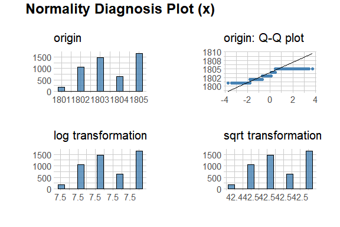

**[ StatutADV ]**

normality test : Shapiro-Wilk normality test

```
 statistic : 0.61228,  p-value : 9.54947E-75
```

skewness and kurtosis

| type | skewness | kurtosis |
| --- | --- | --- |
| original | 0.642 | 1.80 |
| log transformation | 0.592 | 1.44 |
| sqrt transformation | 0.610 | 1.55 |

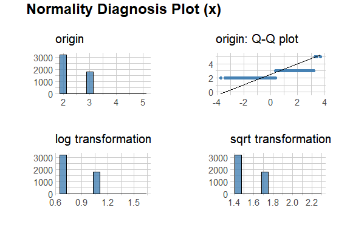

**[ Superficie ]**

normality test : Shapiro-Wilk normality test

```
 statistic : 0.46022,  p-value : 8.19311E-82
```

skewness and kurtosis

| type | skewness | kurtosis |
| --- | --- | --- |
| original | 12.279 | 269.61 |
| log transformation | 0.366 | 7.01 |
| sqrt transformation | 3.250 | 31.81 |

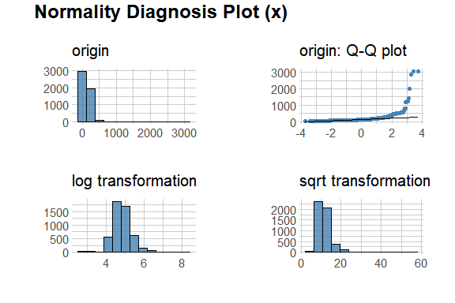

**[ PrixUnitaire ]**

normality test : Shapiro-Wilk normality test

```
 statistic : 0.62868,  p-value : 7.55984E-74
```

skewness and kurtosis

| type | skewness | kurtosis |
| --- | --- | --- |
| original | 4.902 | 42.28 |
| log transformation | -0.798 | 6.35 |
| sqrt transformation | 1.652 | 10.09 |

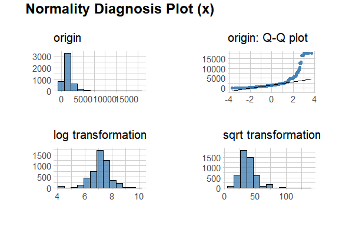

**[ PrixTotal ]**

normality test : Shapiro-Wilk normality test

```
 statistic : 0.74355,  p-value : 2.23303E-66
```

skewness and kurtosis

| type | skewness | kurtosis |
| --- | --- | --- |
| original | 3.946 | 42.50 |
| log transformation | -0.595 | 4.67 |
| sqrt transformation | 1.042 | 5.99 |

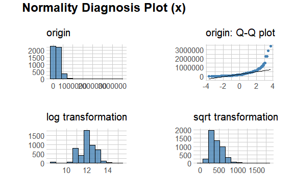

**[ Vers1 ]**

normality test : Shapiro-Wilk normality test

```
 statistic : 0.68943,  p-value : 3.43178E-70
```

skewness and kurtosis

| type | skewness | kurtosis |
| --- | --- | --- |
| original | 4.542 | 50.06 |
| log transformation | -0.444 | 4.26 |
| sqrt transformation | 1.334 | 7.38 |

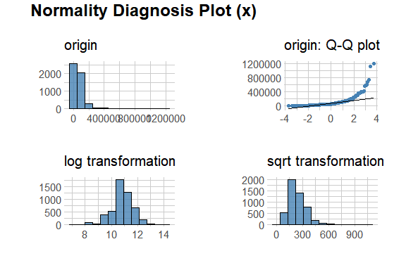

**[ Vers2 ]**

normality test : Shapiro-Wilk normality test

```
 statistic : 0.79336,  p-value : 3.30483E-62
```

skewness and kurtosis

| type | skewness | kurtosis |
| --- | --- | --- |
| original | 2.317 | 13.67 |
| log+1 transformation | -0.792 | 1.69 |
| sqrt transformation | 0.172 | 2.44 |

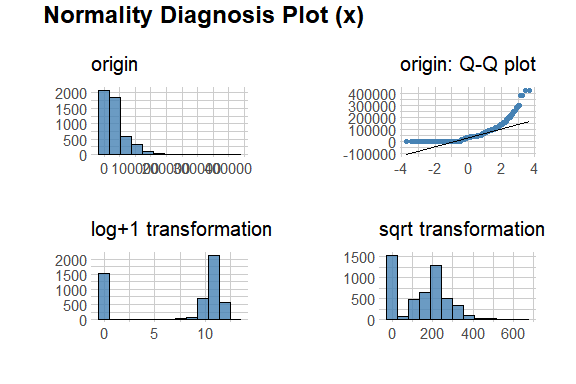

**[ Vers3 ]**

normality test : Shapiro-Wilk normality test

```
 statistic : 0.57569,  p-value : 1.21969E-76
```

skewness and kurtosis

| type | skewness | kurtosis |
| --- | --- | --- |
| original | 3.094 | 16.54 |
| log+1 transformation | 0.694 | 1.52 |
| sqrt transformation | 1.331 | 3.83 |

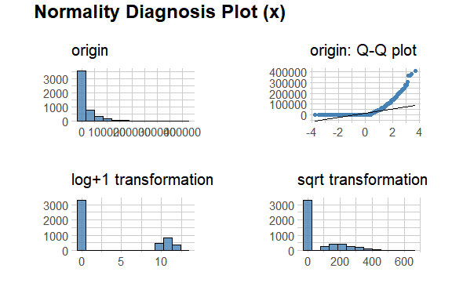

**[ TotalVersement ]**

normality test : Shapiro-Wilk normality test

```
 statistic : 0.75894,  p-value : 3.61444E-65
```

skewness and kurtosis

| type | skewness | kurtosis |
| --- | --- | --- |
| original | 3.836 | 48.53 |
| log transformation | -0.663 | 4.48 |
| sqrt transformation | 0.973 | 5.45 |

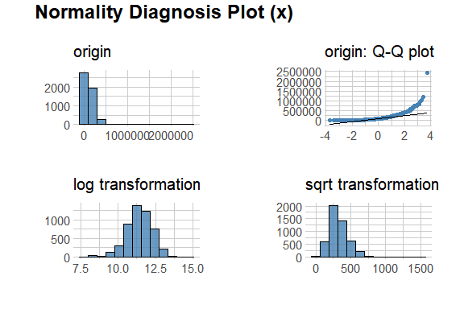

**[ ResteàPayer ]**

normality test : Shapiro-Wilk normality test

```
 statistic : 0.68357,  p-value : 1.43587E-70
```

skewness and kurtosis

| type | skewness | kurtosis |
| --- | --- | --- |
| original | 3.310 | 20.79 |
| log+1 transformation | -1.822 | 4.79 |
| sqrt transformation | 0.852 | 4.28 |

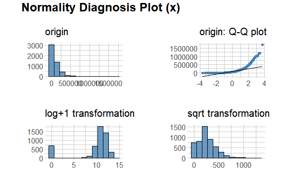

# 3 Relationship Between Variables

## 3.1 Correlation Coefficient

### 3.1.1 Correlation Coefficient by Variable Combination

Table of correlation coefficients (0.5 or more)

| Variable1 | Variable2 | Correlation Coefficient |
| --- | --- | --- |
| ResteàPayer | PrixTotal | 0.827 |
| Vers1 | PrixTotal | 0.803 |
| TotalVersement | PrixTotal | 0.762 |
| TotalVersement | Vers1 | 0.747 |
| TotalVersement | Vers2 | 0.697 |
| PrixTotal | Superficie | 0.642 |
| TotalVersement | Vers3 | 0.621 |
| Vers1 | Superficie | 0.587 |
| TotalVersement | Superficie | 0.548 |
| ResteàPayer | Vers1 | 0.546 |

### 3.1.2 Correlation Plot of Numerical Variables

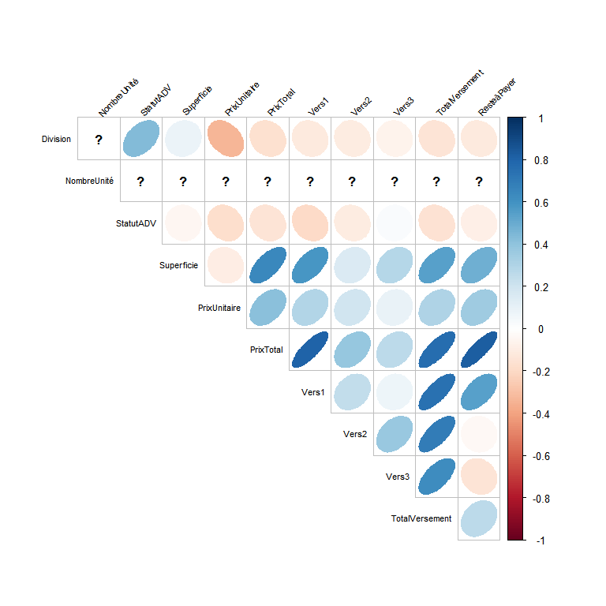

# 4 Target based Analysis